# writeup

Kelly Chen

11/23/2021

```r
library(dplyr)
```

## Step 1

**Generate a single sample from a standard normal distribution of size N = 201.**

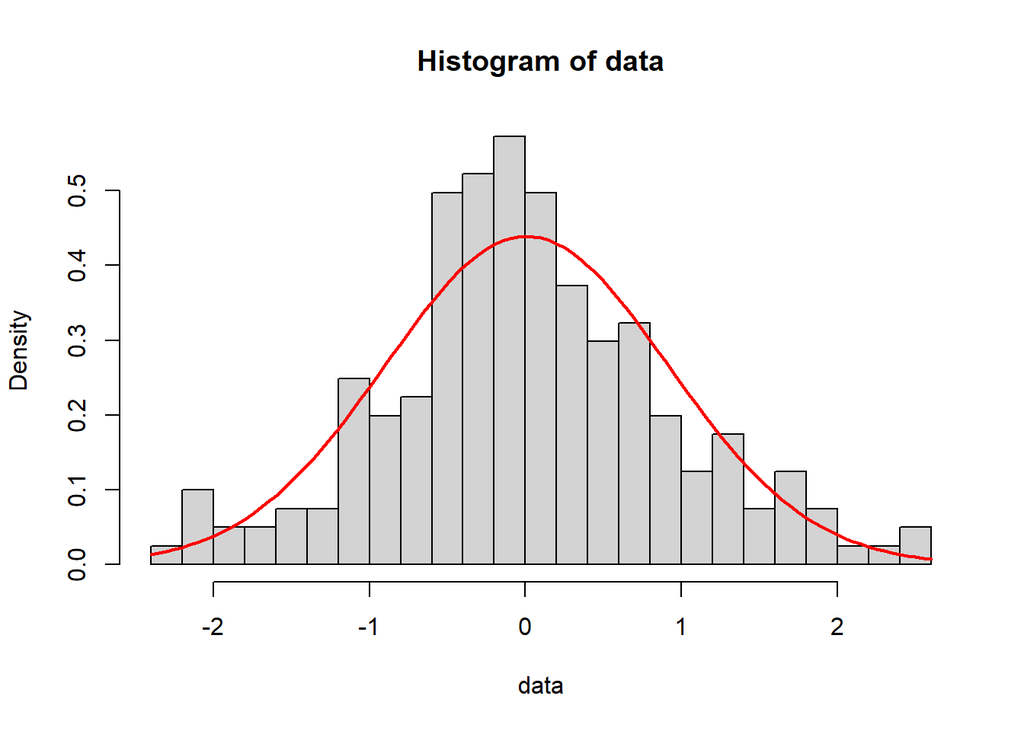

```r
set.seed(100)
size<-201
data<-rnorm(size)
mle_mean<-mean(data)
mle_sd<-sqrt((size-1)/size*var(data))
hist(data,freq = FALSE,breaks=30)
curve(dnorm(x,mean=mle_mean,sd=mle_sd),add=TRUE,col="red",lwd=2)
```

We utilized maximum likelihood estimation to estimate the mean and standard deviation of the data we generated from rnorm(). We overlayed the PDF on the histogram to show the sampled normal distribution.

## Step 2

**Approximate the sampling distribution of the median, conditional on the estimate of the distribution in the previous step**

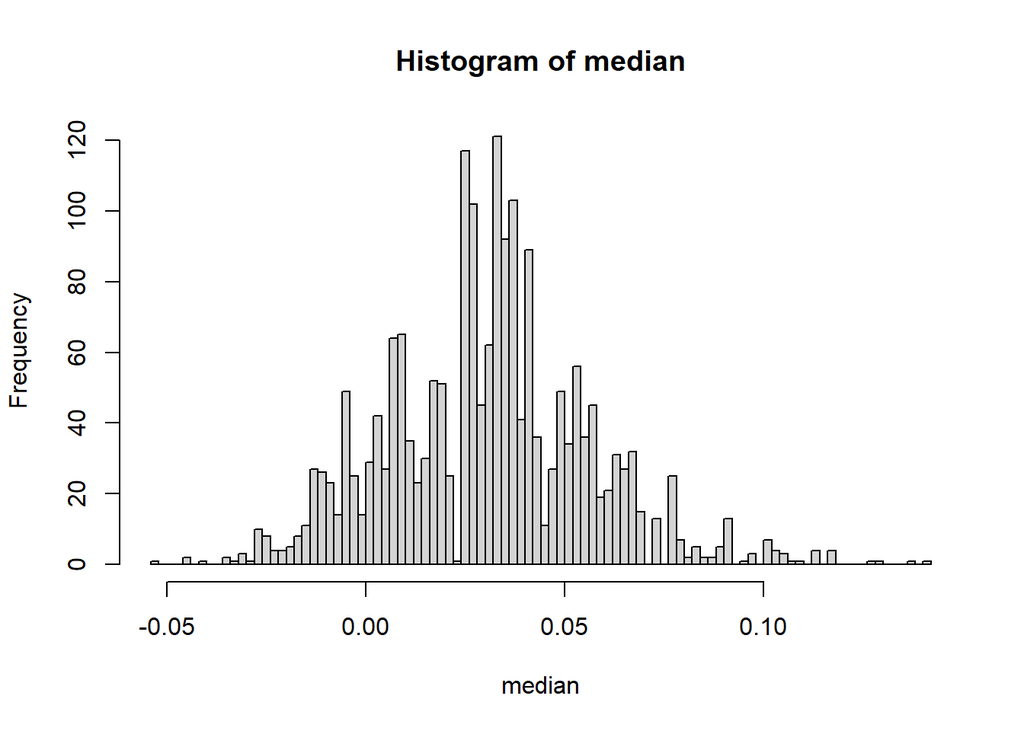

```r
r<-2000
data_1<-rnorm(r,mle_mean,mle_sd)
median<-rep(NA,r)
for (i in 1:r){
  s<-sample(data_1,length(data_1),replace=TRUE)
  median[i]<-median(s)
}
hist(median,breaks=100)
```

From the estimated parameters from mle previously, we simulated the median for 2000 times and get the sampled distribution of the median. The histogram is showing the distribution of median which is also normally distributed.

## Step 3

**Calculate a 95% confidence interval from the approximated sampling distribution**

```r
alpha<-0.05
ci<-quantile(median,c(alpha/2,1-alpha/2))
ci
```

```
##        2.5%       97.5%
## -0.01595777  0.08666404
```

```r
ci[1]<0
```

```
## 2.5%
## TRUE
```

```r
ci[2]>0
```

```
## 97.5%
##  TRUE
```

**Explain The concept of coverage probability**

In statistics, the coverage probability of a technique for calculating a confidence interval is the proportion of the time that the interval contains the true value of interest.

A confidence interval (CI) is an interval estimate that potentially contains the population parameter. Because the CI is an estimate, it is computed from a sample. A confidence interval for a parameter is derived by knowing (or approximating) the sampling distribution of a statistic.

Due to sampling variation, the confidence interval for a particular sample might not contain the parameter. A 95% confidence interval means that if you collect a large number of samples and construct the corresponding confidence intervals, then about 95% of the intervals will contain or cover the parameter.

## Step 4

**Use simulation to report the result**

```r
ci_median<-function(n=2000,size=201){
  data<-rnorm(size)
  mle_mean<-mean(data)
  mle_sd<-sqrt(((size-1)/size)*var(data))
  median<-rbeta(n,size,size) %>%qnorm(mean=mle_mean,sd=mle_sd)
  alpha<-0.05
  ci<-quantile(median,c(alpha/2,1-alpha/2))
  return (ci[1] < 0 & ci[2] > 0)
}

ci_list<-NA
for (i in 1:2000){
  ci_list[i]<-ci_median()
}


mean(ci_list)
```

```
## [1] 0.917
```

## Step 5

**Describe how you might change the simulation to learn more about the operating characteristics of your chosen method for constructing the 95% confidence interval.**

First I can try to change the sample sizes of the simulation, since the larger the sample sizes the more accurate the confidence interval might be. Another modification could be changing the number of simulation, the larger the number of simulation, the confidence interval would also be more accurate.